# ミュラーリヤー錯視

## 1. 目的 (Introduction)

本研究では、ミュラーリヤー錯視における矢羽の角度が錯覚量に及ぼす影響について検討する。ミュラーリヤー効果とは同じ線分であるにもかかわらず、その両端に付加される矢印の向き（内向・外向）によって、線分の長さが異なるように知覚される視覚的錯視現象である（[@foster]）。 本実験の仮説は「角度が鋭い（15条件）の方が、鈍い（75条件）よりも錯覚量が有意に大きくなる。矢羽の長さ（20px条件と50px条件）によって、錯覚量に有意な差が見られる。」とした。

## 2. 方法 (Method)

### 参加者

12名のデータを収集した。

### 装置と材料

オンライン実験プラットフォーム（jsPsych）を使用して作成し、GitHab Pages上に公開した。参加者は各自PCのブラウザから参加した。

## 3. 結果 (Results)

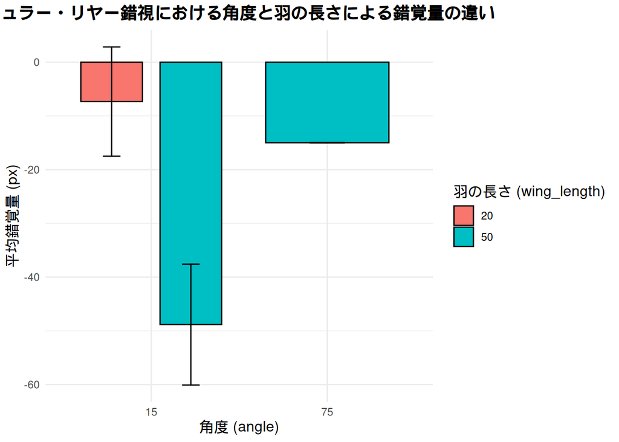

```r
# ==============================================================================
# ミュラー・リヤー錯視データの集計および可視化スクリプト
# ==============================================================================

# 1. パッケージの読み込み
library(tidyverse)
# 2. データの読み込み
clean_data <- read_csv("clean_data.csv")
# ※列名「wing_lengle」が存在する場合の互換性対応
if ("wing_lengle" %in% colnames(clean_data) && !"wing_length" %in% colnames(clean_data)) {
  clean_data <- clean_data %>% rename(wing_length = wing_lengle)
}

# 3. データの集計
summary_data <- clean_data %>%
  mutate(
    error_amount = parse_number(as.character(error_amount)),
    angle        = parse_number(as.character(angle)),
    wing_length  = parse_number(as.character(wing_length))
  ) %>%
  group_by(subject_id, angle, wing_length) %>%
  summarise(
    mean_error_subj = mean(error_amount, na.rm = TRUE),
    .groups = "drop"
  ) %>%
  group_by(angle, wing_length) %>%
  summarise(
    mean_error = mean(mean_error_subj, na.rm = TRUE),
    sd_error   = sd(mean_error_subj, na.rm = TRUE),
    n          = n(),
    se_error   = ifelse(n > 1, sd_error / sqrt(n), 0),
    .groups    = "drop"
  ) %>%
  mutate(
    angle = as.factor(angle),
    wing_length = as.factor(wing_length)
  )

# 4. ggplot2 を用いた2要因エラーバー付き棒グラフの描画
p <- ggplot(summary_data, aes(x = angle, y = mean_error, fill = wing_length)) +
  geom_bar(
    stat = "identity",
    position = position_dodge(0.9),
    color = "black",
    width = 0.7
  ) +
  geom_errorbar(
    aes(ymin = mean_error - se_error, ymax = mean_error + se_error),
    position = position_dodge(0.9),
    width = 0.2
  ) +
  labs(
    title = "ミュラー・リヤー錯視における角度と羽の長さによる錯覚量の違い",
    x = "角度 (angle)",
    y = "平均錯覚量 (px)",
    fill = "羽の長さ (wing_length)"
  ) +
  theme_minimal(base_family = "sans") +
  theme(
    plot.title = element_text(hjust = 0.5, face = "bold", size = 14),
    axis.title = element_text(size = 12),
    legend.title = element_text(size = 12)
  )

# 5. グラフの画面表示と画像保存
print(p)
```

```r
ggsave("result_graph.png", plot = p, width = 8, height = 6, dpi = 300)
```